# First Hybrid GIS Tests

03-28-2017

First tests of the USAMS SNICS-134 Hybrid gas ion source.

```r
library(amstools)
library(tidyverse)
library(ggplot2)
```

# Flow rates

## Calculated flow

### Pouiselles equation

$$Q = \frac{\Delta P \pi R^4}{8 \mu \Delta x}$$
Where $\Delta P$ is change in pressure (Pa ($\frac{kg}{m \cdot s^2}$)), $R$ is radius of pipe (m), $\mu$ is dynamic viscosity ( $P \cdot s$ ($\frac{kg}{s \cdot m}$)), and $\Delta x$ is the length of the pipe (m). Q is in $\frac{m^3}{s}$

## measured flow

### Leak detector

Measured leak rate using Helium leak detector. Ran capillary to KF adapter flange. Pressures in kPa, leak rates in $\frac{Pa\cdot m^3}{s}$. Leak detector switched to gross leak mode between 150 kPa and 200 kPa.

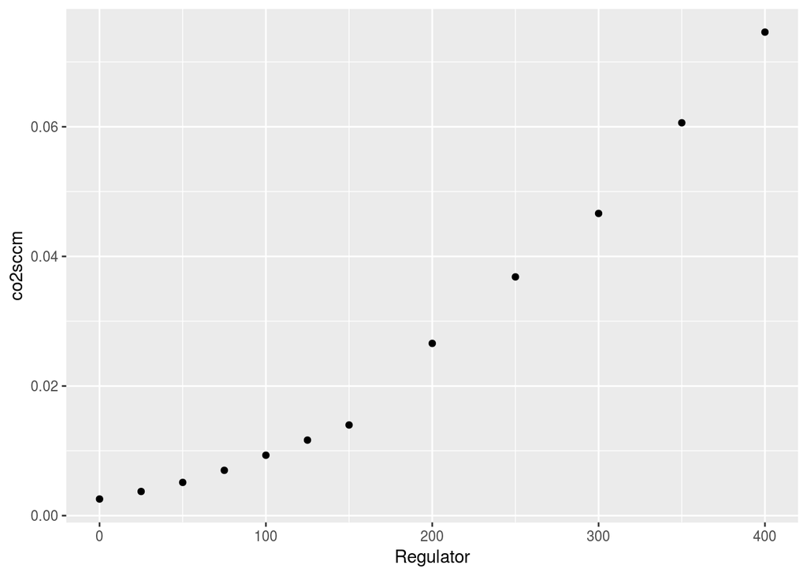

```r
ldflow <- read.csv("../Data/HeLeakCapillaryFlow.csv", skip = 3)

# convert to sccm
ldflow <- mutate(ldflow, sccm = Leakrate / 0.0016,
                 co2sccm = sccm * 14.9/19.97) # co2/He viscosity
# factor for He vs CO2

ggplot(ldflow, aes(Regulator, co2sccm)) + geom_point()
```

## Functions for flow and efficiency

```r
# convert L CO2 to atoms C
lCO2toatC <- function (vol) {
  molC <- vol * 1/22.4 # 22.4 L of gas per mole at stp
  atC <- molC * 6.022E23
  atC
}


# convert current in A to atoms C/sec
CcurtoatC <- function(cur, cs){
  at12C <- cur * 6.25E18 # electrons per coulomb
  at12C <- at12C / cs # divide by charge state
  at12C
}

# convert delta pressure in Pa to flow in m^3/s
prestoflow <- function(dp, r = 2.5E-5, u = 1.49E-5, l = 8.2 ) {
  # r = radius of capillary
  # l = length of capillary
  # u = viscosity kg/m
  flow <- dp * pi * r^4 / 8 / u / l
  flow
}

# convert gauge kPa to uL/min
flowcalc <- function(pres) {
  dppa <- pres * 1E3 #convert kPa to Pa
  flowcms <- prestoflow(dppa)
  flowuls <- flowcms * 1E6 * 1E3
  flowulm <- flowuls * 60
  flowulm
}

# calculate efficiency from ml/m CO2 and uA C12
hgis_eff <- function(ulm, uA, cs = 3) {

  # if flow is zero or less, efficiency doesn't make sense
  ulm <- ifelse(ulm <= 0, NA, ulm)

  vol <- ulm * 1E-6 # conv to L
  cur <- uA * 1E-6 # conv to A
  atCin <- lCO2toatC(vol) / 60 # gives atoms/s
  atC12out <- CcurtoatC(cur, cs)
  atCout <- atC12out / .99 # 99% of C is 12C, we need total C
  atC12out / atCin
}
```

# First Day

USAMS032817

```r
data <- readResfile("/mnt/shared/USAMS/Results/USAMS032817R.txt") %>%
  mungeResfile()
```

## Currents

For the first target, we turned up the gas supply pressure while measuring source current at the high energy FC. These currents are roughly equivalent to le12C.

- TODO: Blank current subtraction

```r
cur <- read.delim("../Data/1sttestcurrents.csv") %>%
  mutate(flow = flowcalc(regp),
         eff = hgis_eff(flow, he12c)) %>%
  filter(t > 5)
cur
```

```
##    t regp sourcep he12c c1412       flow         eff
## 1 10    0 3.0e-07   1.2  1.10  0.0000000          NA
## 2 13    5 3.2e-07   1.4  1.00  0.3766527 0.017282408
## 3 15   10 3.5e-07   2.2  1.10  0.7533053 0.013579035
## 4 20   50 3.9e-07   3.2  1.03  3.7665267 0.003950265
## 5 25  100 5.3e-07   4.6  1.10  7.5330535 0.002839253
## 6 28  150 7.1e-07   5.5  1.05 11.2995802 0.002263173
## 7 34  200 9.4e-07   6.0  1.05 15.0661069 0.001851687
## 8 40  250 1.2e-06   7.0  1.06 18.8326337 0.001728241
## 9 45  300 1.6e-06   7.0  1.05 22.5991604 0.001440201
```

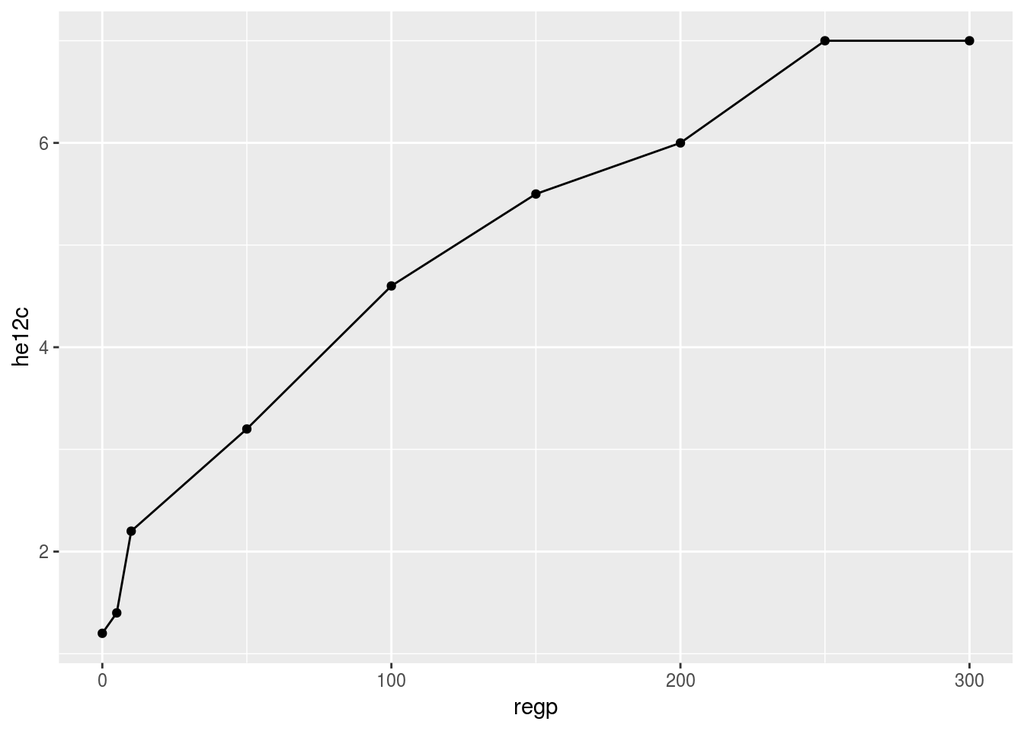

```r
ggplot(cur, aes(regp, he12c)) + geom_line() + geom_point()
```

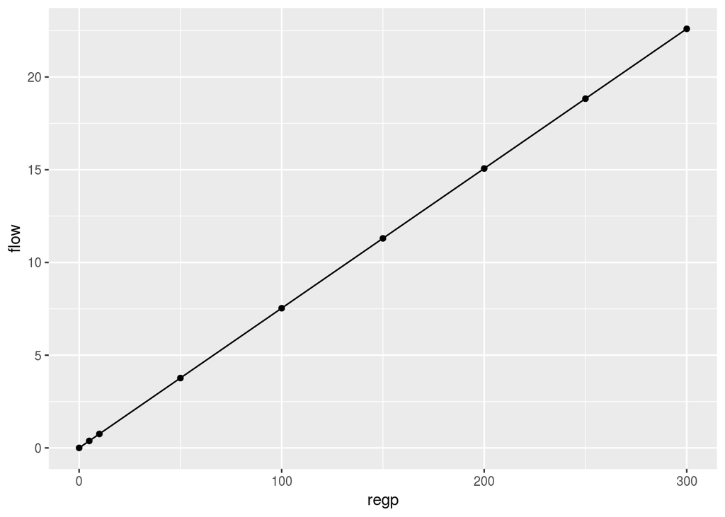

```r
ggplot(cur, aes(regp, flow)) + geom_line() + geom_point()
```

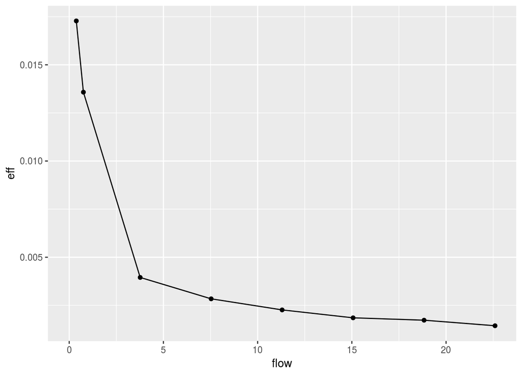

```r
ggplot(cur, aes(flow, eff)) + geom_line() + geom_point()
```

Currents were very stable after an initial burn in of ~10m. Initial current started at ~12uA without gas on target and decayed (roughly) exponentially to a minimum around 1.2uA.

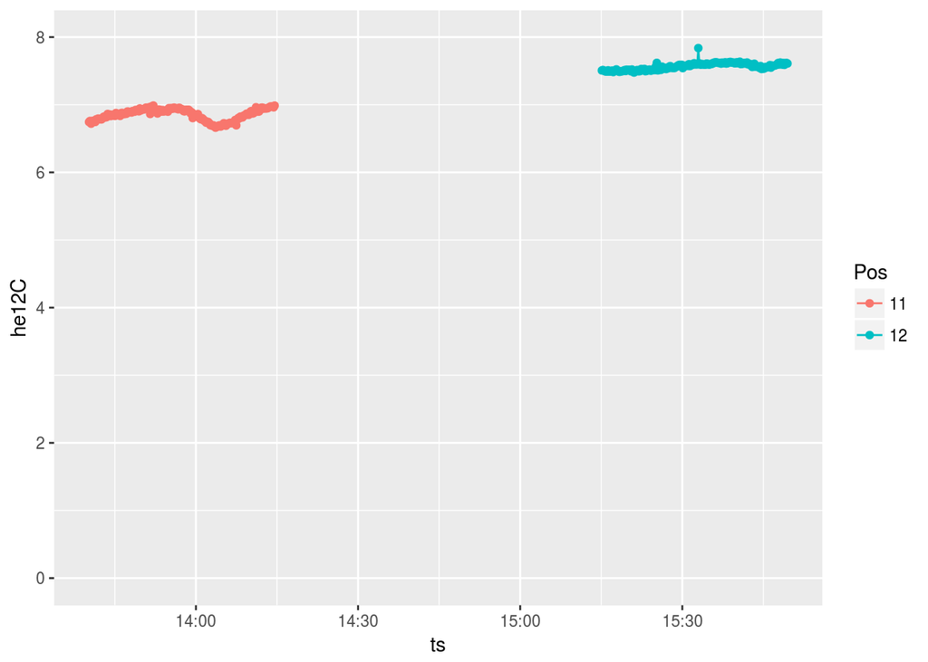

```r
data %>% filter(Pos %in% c(11,12)) %>% ggplot(aes(ts, he12C, color = Pos)) + geom_line() + geom_point() + ylim(c(0,8))
```

## Ratios

### Summary table

```r
data.s <- data %>% group_by(Pos) %>% summarize(c1412.m = mean(X14.12he),
                                         c1412.s = sd(X14.12he),
                                         c1412.sdr = c1412.s/c1412.m,
                                         c1412.se = se(X14.12he),
                                         c1412.ser = c1412.se/c1412.m,
                                         counts = sum(CntTotGT),
                                         interr = 1/sqrt(counts))
knitr::kable(data.s, digits = 4)
```

| Pos | c1412.m | c1412.s | c1412.sdr | c1412.se | c1412.ser | counts | interr |
| --- | --- | --- | --- | --- | --- | --- | --- |
| 2 | 0.0012 | 0.0005 | 0.4395 | 0.0002 | 0.1390 | 390 | 0.0506 |
| 3 | 0.0012 | 0.0004 | 0.3462 | 0.0001 | 0.1095 | 400 | 0.0500 |
| 6 | 1.0414 | 0.0090 | 0.0086 | 0.0028 | 0.0027 | 262777 | 0.0020 |
| 7 | 1.0420 | 0.0040 | 0.0038 | 0.0013 | 0.0012 | 258677 | 0.0020 |
| 11 | 1.0512 | 0.0829 | 0.0789 | 0.0062 | 0.0059 | 27146 | 0.0061 |
| 12 | 0.0113 | 0.0084 | 0.7422 | 0.0006 | 0.0553 | 323 | 0.0556 |

### Plots

Boxplots of modern and dead samples. Ratios were essentially stable over time. Positions < 10 are solid samples run for comparison.

#### Modern

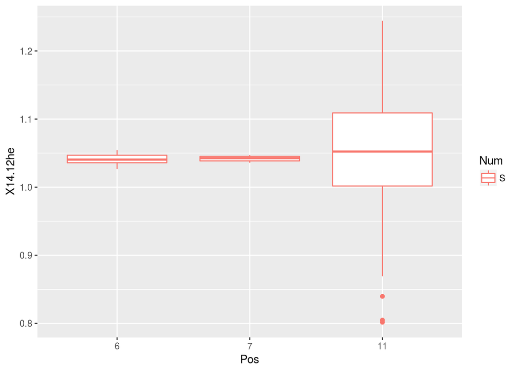

```r
data %>% filter(X14.12he > .4) %>% ggplot(aes(Pos, X14.12he, color = Num)) +
        geom_boxplot()
```

#### Dead

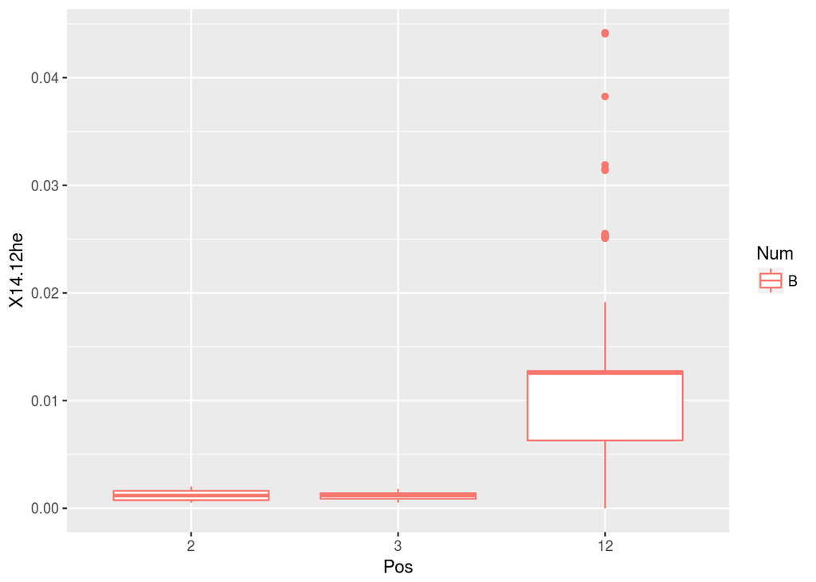

```r
data %>% filter(X14.12he < .4) %>% ggplot(aes(Pos, X14.12he, color = Num)) +
        geom_boxplot()
```

# Second Day

```r
#
data2 <- readResfile("/mnt/shared/USAMS/Results/USAMS040317R.txt") %>%
  filter(Pos == 13) %>%
  mungeResfile()

# Assign Run numbers
counter <- 0
Run <- c(1:190)
for (i in 1:nrow(data2)) {
  if (data2$Meas[i] == 1) {
    counter <- counter + 1
  }
  Run[i] <- counter
}
data2$Run <- Run

# Load pressure data
pres <- read.csv("../Data/USAMS040317Pressure.csv")
pres$Run <- as.numeric(row.names(pres))

# Join to run data
data2 <- inner_join(data2, pres) %>%
  mutate(flow = flowcalc(Bottle),
         eff = hgis_eff(flow, he12C))
# summarize
d2.s <- data2 %>% group_by(Run, Bottle, Source) %>% summarize(le12C = mean(le12C),
                                              he12C = mean(he12C),
                                              C1412he = mean(X14.12he),
                                              cor1412he = mean(cor1412he),
                                              eff = mean(eff))
```

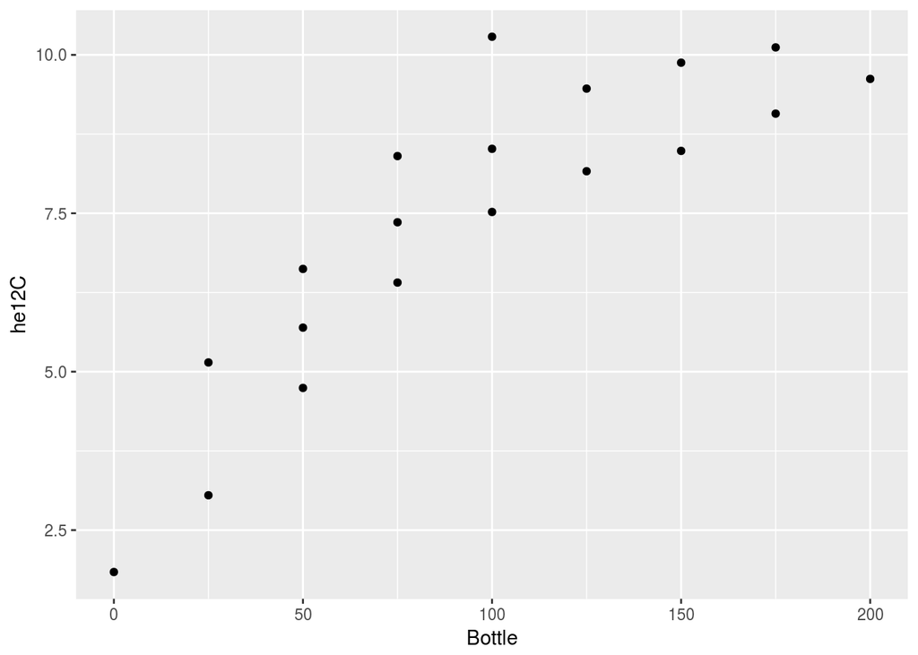

```r
ggplot(d2.s, aes(Bottle, he12C)) + geom_point()
```

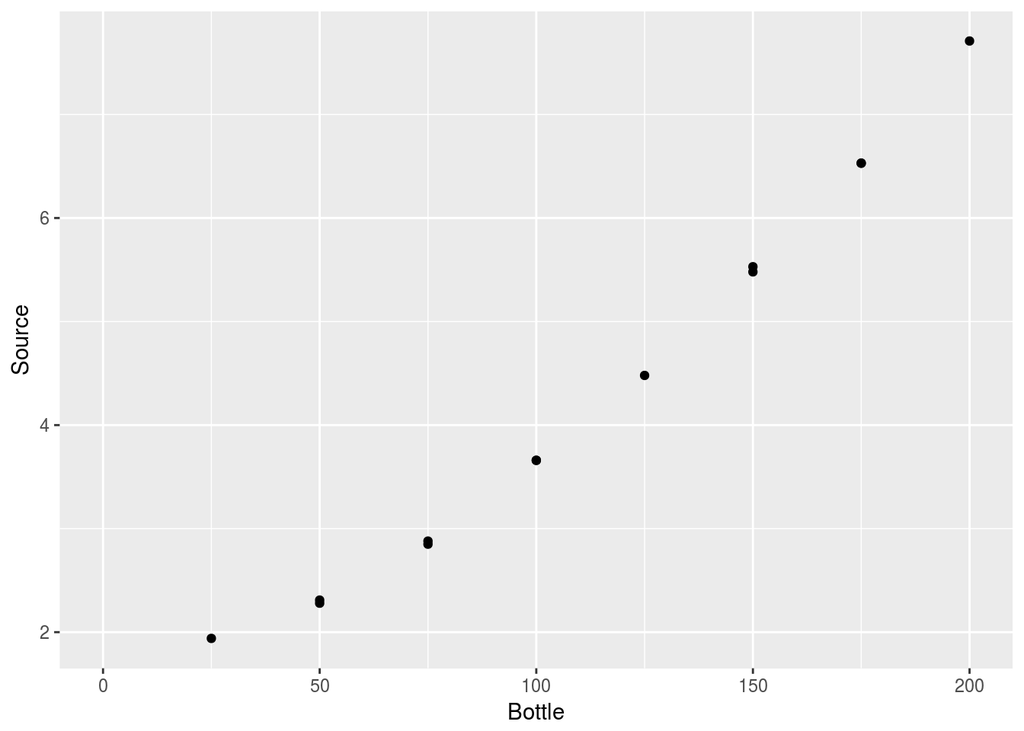

```r
ggplot(d2.s, aes(Bottle, Source)) + geom_point()
```

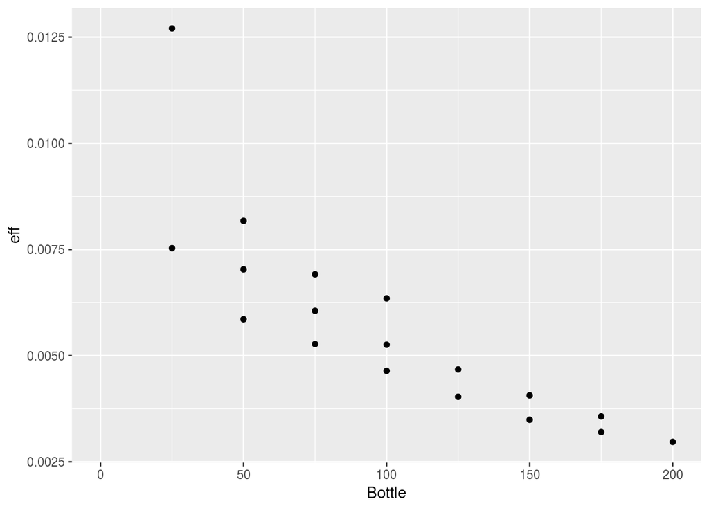

```r
ggplot(d2.s, aes(Bottle, eff)) + geom_point()
```

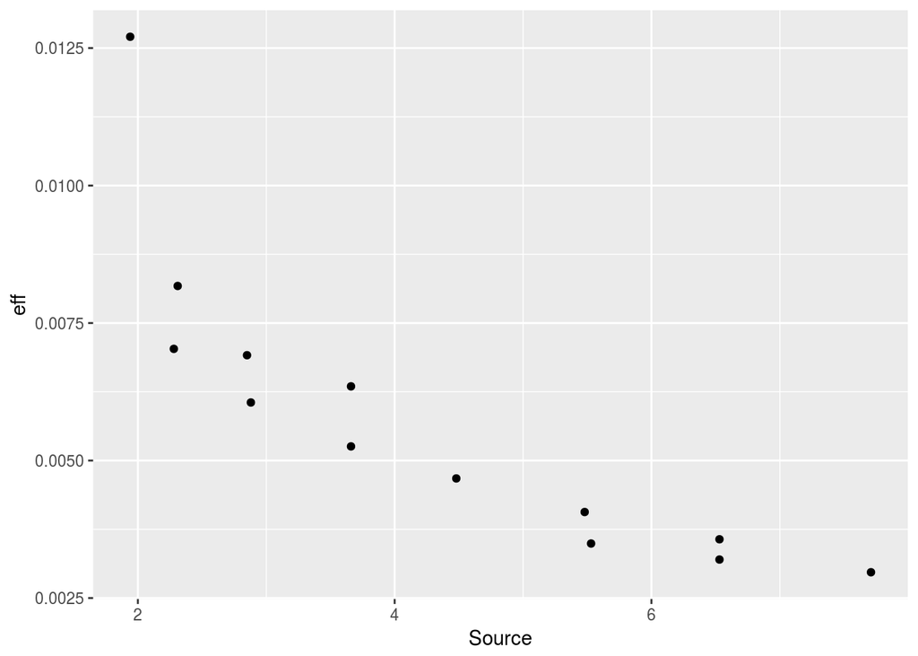

```r
ggplot(d2.s, aes(Source, eff)) + geom_point()
```

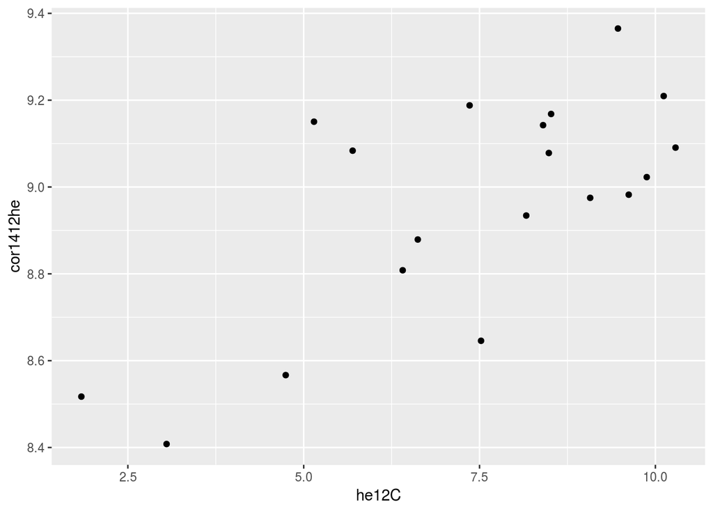

```r
ggplot(d2.s, aes(he12C, cor1412he)) + geom_point()
```